# mwmap: A Complete Guide to Mapping Malawi in R

# 8 Complete Worked Examples

These examples bring together multiple mwmap functions to produce polished, multi-layer maps of the kind you might include in a research paper, government report, or programme dashboard.

## 8.1 Example 1 — Malaria burden map

This example builds a complete publication-ready map that combines a categorical choropleth, lake overlay, outline highlights on the major cities, and text labels. The key insight is that each element is a separate layer added with `+`, and the final `mw_layout()` call applies consistent titling and styling to the whole figure.

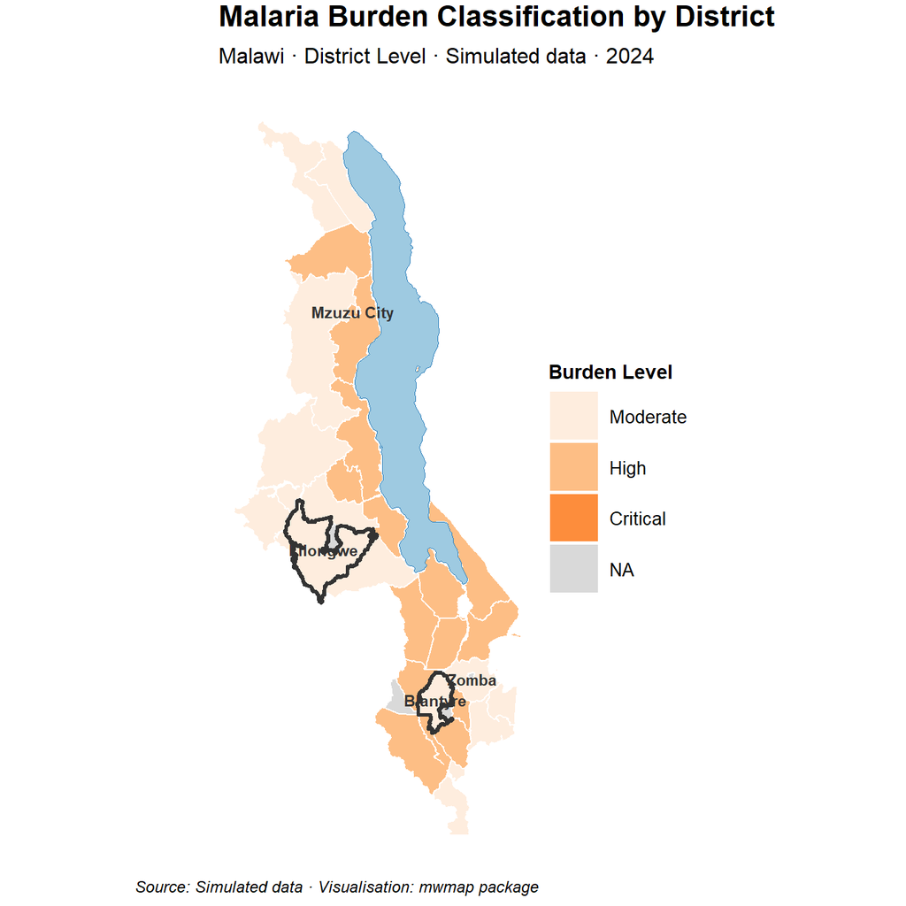

Figure 33: A complete, multi-layer malaria burden map suitable for publication.

```r
# Step 1: classify districts into burden tiers
health_data$burden <- cut(
  health_data$rate_per_1000,
  breaks = c(0, 3, 5, 8, 12, Inf),
  labels = c("Minimal", "Low", "Moderate", "High", "Critical"),
  ordered_result = TRUE
)

# Step 2: join to geometry
map_df <- mw_join(health_data, quiet = TRUE)

# Step 3: build the map layer by layer
mw_map(
  data = map_df,
  fill = "burden",
  lakes = TRUE,
  border_color = "white",
  border_size = 0.4
) +
  scale_fill_mw(
    "malaria",
    discrete = TRUE,
    name = "Burden Level",
    na.value = "grey85"
  ) +
  mw_highlight(
    districts = c("Blantyre", "Lilongwe"),
    outline_only = TRUE,
    color = "#333333",
    size = 1
  ) +
  mw_labels(
    districts = c("Blantyre", "Lilongwe", "Mzuzu City", "Zomba"),
    size = 3,
    color = "#333333"
  ) +
  mw_layout(
    title = "Malaria Burden Classification by District",
    subtitle = "Malawi · District Level · Simulated data · 2024",
    caption = "Source: Simulated data · Visualisation: mwmap package",
    legend_position = "right"
  )
```

## 8.2 Example 2 — Regional vaccination coverage

This example uses `mw_regions()` to show a regional-level indicator. The darker the green, the higher the vaccination coverage. We encode the coverage values by manually mapping each region to a colour from the `"vaccination"` palette — darker for higher coverage. The result communicates both geography and relative performance at a glance.

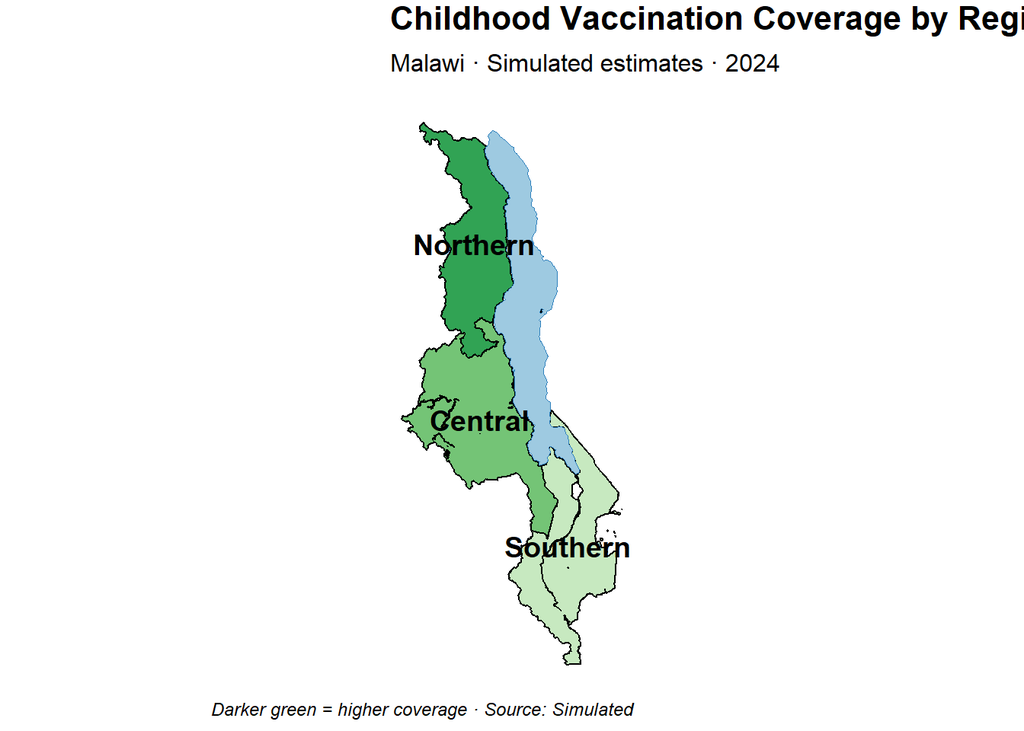

Figure 34: Vaccination coverage at the regional level. Darker green = higher coverage.

```r
mw_regions(
  region_colors = c(
    "Northern" = "#31A354", # highest coverage → darkest green
    "Central" = "#74C476",
    "Southern" = "#C7E9C0" # lowest coverage → lightest green
  ),
  labels = TRUE,
  label_size = 5,
  label_face = "bold",
  lakes = TRUE
) +
  mw_layout(
    title = "Childhood Vaccination Coverage by Region",
    subtitle = "Malawi · Simulated estimates · 2024",
    caption = "Darker green = higher coverage · Source: Simulated"
  )
```

## 8.3 Example 3 — Infrastructure overlaid on burden data

This example combines two data sources on a single map: the district-level health burden (continuous choropleth) and the locations of health facilities (points coloured by facility level). This dual-layer approach allows the reader to see both the health burden and the distribution of health infrastructure simultaneously — and to immediately spot areas where burden is high but facilities are sparse.

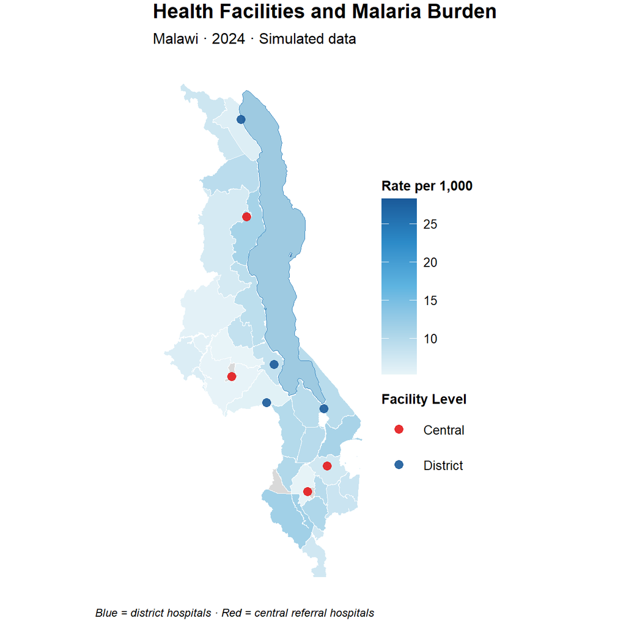

Figure 35: Health burden choropleth with facility locations overlaid. High-burden areas with few facilities become immediately visible.

```r
mw_map(
  data = map_df,
  fill = "rate_per_1000",
  lakes = TRUE,
  border_color = "white",
  border_size = 0.3
) +
  scale_fill_mw(
    "health",
    name = "Rate per 1,000",
    na.value = "grey85"
  ) +
  mw_points(
    facilities,
    lon,
    lat,
    color = "level",
    size = 3,
    alpha = 0.9
  ) +
  scale_color_manual(
    values = c("Central" = "#E41A1C", "District" = "#1a5a9a"),
    name = "Facility Level"
  ) +
  mw_layout(
    title = "Health Facilities and Malaria Burden",
    subtitle = "Malawi · 2024 · Simulated data",
    caption = "Blue = district hospitals · Red = central referral hospitals",
    legend_position = "right"
  )
```

## 8.4 Example 4 — Traditional authority detail

This example zooms into a single district (Lilongwe) to show the TA-level structure. This kind of map is useful for district health offices, local programme teams, and field research that needs to operate at the sub-district level. The thick district boundary provides a frame of reference; the TA name labels let the reader identify each sub-unit by name.

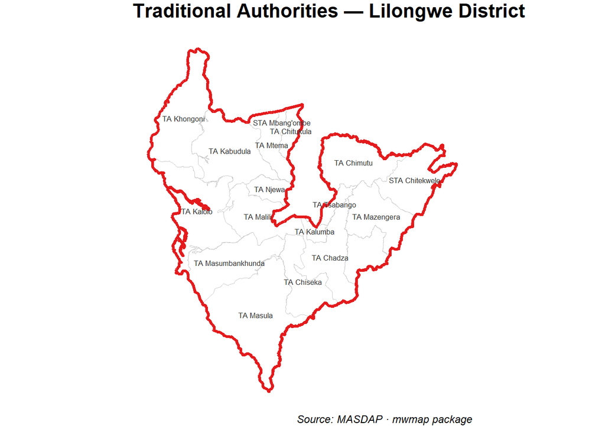

Figure 36: Traditional Authorities in Lilongwe district. The thick red border is the district boundary; thin grey lines are TA boundaries.

```r
mw_ta_map(
  districts = "Lilongwe",
  fill = "white",
  border_color = "grey80",
  border_size = 0.2,
  district_border = TRUE,
  district_border_color = "#E41A1C",
  district_border_size = 1.2,
  labels = TRUE,
  label_size = 2.2,
  label_color = "#333333"
) +
  mw_layout(
    title = "Traditional Authorities — Lilongwe District",
    caption = "Source: MASDAP · mwmap package"
  )
```

# 9 Tips and Best Practices

**TipAlways map rates, not raw counts**

A map of raw case counts is almost always misleading because it reflects population size as much as the variable of interest. Lilongwe and Blantyre will have more of almost everything simply because they are the largest districts. Before mapping any count variable, divide by the appropriate denominator:

```r
# Incidence rate per 1,000 population
data$rate_per_1000 <- data$cases / data$population * 1000

# Percentage of target reached
data$coverage_pct <- data$reached / data$target * 100
```

The geographic pattern on a rate map is often dramatically different from a count map and reveals the underlying epidemiology or social geography in a way that counts simply cannot.

**TipBuild complex maps layer by layer**

Rather than trying to pass every option to a single function call, build your map incrementally and check the output at each step. This makes it far easier to debug problems — if something looks wrong, print the map after each `+` to find which layer is causing the issue:

```r
p <- mw_map(data = joined, fill = "rate")
p <- p + scale_fill_mw("malaria", name = "Rate")
p <- p + mw_highlight(c("Lilongwe", "Blantyre"), outline_only = TRUE)
p <- p + mw_labels(districts = c("Lilongwe", "Blantyre"))
p <- p + mw_layout(title = "My Map", caption = "Source: ...")
p
```

**TipUse `quiet = TRUE` in R Markdown and Quarto documents**

Several mwmap functions print informational messages to the console by default. These messages are helpful interactively but clutter rendered documents. Suppress them with `quiet = TRUE`:

```r
joined <- mw_join(my_data, quiet = TRUE)
mw_choropleth(my_data, my_variable, quiet = TRUE)
```

Alternatively, set `message: false` in the Quarto chunk options to suppress messages globally for all chunks in the document.

**TipCombine with ggplot2 extension packages**

Because `mw_map()` returns a plain ggplot2 object, any ggplot2 extension package works on top of it without modification:

- **`patchwork`** — arrange multiple maps side by side or in a grid.
- **`ggspatial`** — add scale bars and north arrows (also available via `scale_bar = TRUE` and `north_arrow = TRUE` in `mw_map()`).
- **`ggrepel`** — non-overlapping labels via `mw_label_repel()`.
- **`plotly`** — interactive maps via `interactive = TRUE` in `mw_map()` or `mw_choropleth()`.

**NoteInteractive maps with plotly**

Pass `interactive = TRUE` to `mw_map()` or `mw_choropleth()` to get a pannable, zoomable map in HTML documents and Shiny apps:

```r
# Requires: install.packages("plotly")
mw_choropleth(
  health_data,
  rate_per_1000,
  palette     = "malaria",
  title       = "Malaria Incidence Rate",
  interactive = TRUE
)
```

Note that `mw_layout()` and other ggplot2 layer functions cannot be added to a plotly object with `+`. Apply all ggplot2 modifications before converting to interactive, or call `plotly::ggplotly(your_ggplot_map)` yourself at the end.

# 10 Function Reference Summary

For full documentation on any function, including all arguments and additional examples, use R’s built-in help: `?mw_map`, `?mw_choropleth`, `?mw_join`, etc.

Complete mwmap function reference

[output not shown]

**mwmap** is developed and maintained by Chifundo Bita. Source code and issue tracker: github.com/bitacanalytics/mwmap Install from CRAN: `install.packages("mwmap")` Install development version: `remotes::install_github("bitacanalytics/mwmap")`